# LASSO Civil War Predictor

ry-rousseau

2024

### Exercise 1: Gradient Descent Algorithm Analysis

- **Objective**: Compare Stochastic Gradient Descent (SGD) with SGD + Momentum
- **Implementation**: Custom algorithms built from scratch
- **Analysis**: Performance comparison, convergence behavior, and theoretical discussion

### Exercise 2: Custom Regularized Regression Function

- **Objective**: Build an automated model selection function for polynomial regression
- **Features**: Ridge regularization, cross-validation, hyperparameter optimization
- **Output**: Optimal polynomial degree, lambda value, and trained model

### Exercise 3: Civil War Prediction Model

- **Objective**: Binary classification on real-world political science data
- **Method**: LASSO logistic regression with feature selection
- **Dataset**: 53 socioeconomic/political predictors across country-years

## Exercise 1

#### Figure 1: Negative log-likelihood over time by algorithim

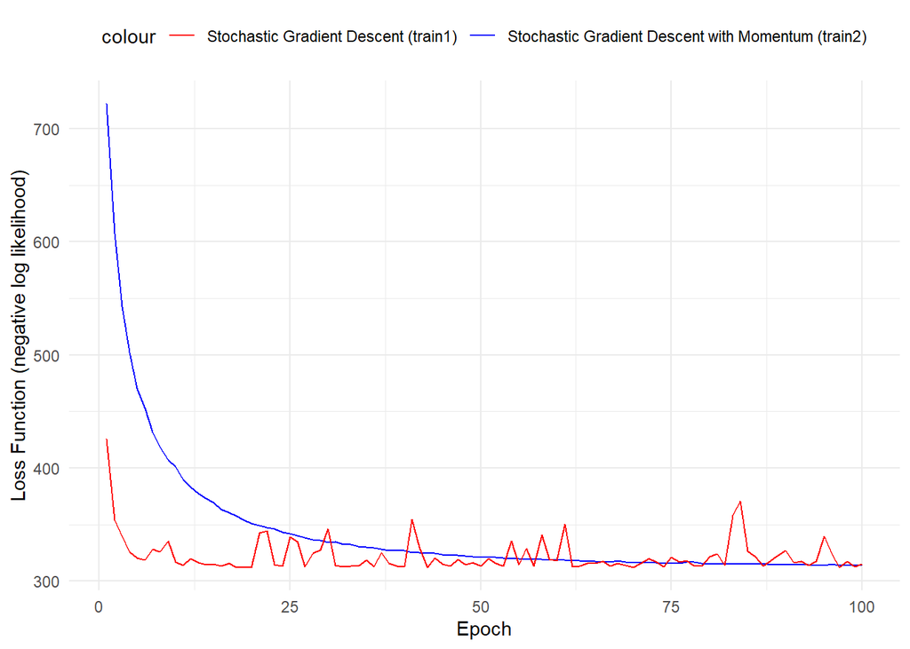

#### Figure 2: Table of computational time, final coefficients, and final error by algorithim

```
## # A tibble: 2 × 4
##   Method                                 Time_Taken Final_Coefficients Final_NLL
##   <chr>                                  <drtn>     <chr>                  <dbl>
## 1 Traditional Stochastic Gradient Desce… 6.685670 … 3.1660217  1.6327…      314.
## 2 Stochastic Gradient Descent with Mome… 4.696943 … 3.6808136  1.8921…      315.
```

Question 1:

Both algorithms are implementations of stochastic gradient descent (SGD). The key difference in the ‘train2’ algorithm is the inclusion of the momentum hyper parameter $m$ and the velocity vector $v_t$. This implements a ‘stochastic gradient descent with momentum’ (SGDM) algorithm. This algorithm modifies the parameter update step from traditional SGD as follows:

$$\theta_{t+1} = \theta_t + v_{t+1}$$

where $\theta_t$ is the model parameter at time $t$, and $v_{t+1}$ is the parameter velocity term at time $t+1$. Essentially, the update step is the velocity term, which is defined according to the following:

$$v_{t+1} = m v_t + \eta \nabla
f(\theta_t)$$

Question 2:

Moreover, the algorithm is sensitive to the momentum hyperparameter $m$. If $m$ is too high, the algorithm may overshoot the minimum and oscillate around it. If $m$ is too low, the algorithm may not be able to escape saddle points and plateaus in the loss function, and model accuracy will decrease. Lower velocity will also decrease algorithm efficiency. A middleground in this trade-off may exist, however a better approach is to decrease momentum as the algorithm progresses so that it does converge on a true minimum, particularly in later epochs. This can be done by implementing a variation on SGDM called Nesterov Momentum (Nesterov 1983), which introduces a look-ahead step and modifies equations according to the following:

Look-ahead step:
$$\theta_{\text{temp}} =
\theta_t + \mu v_t$$

Velocity update:
$$v_{t+1} = \mu v_t +
\eta \nabla f(\theta_{\text{temp}})$$

Parameter update:
$$\theta_{t+1} =
\theta_t + v_{t+1}$$

Nesterov momentum fixes the problem of overshooting the minimum by calculating the gradient of the loss function at a look-ahead position (calculated based on velocity), and this enables the algorithim to temper its momentum term based on the observed future gradient. It avoids taking steps that are too large (overshooting) or steps that are too small (resulting in longer convergence) (Kochenderfer and Wheeler, 2019). Essentially, this retains the advantages of efficiency offered by momentum while also ensuring model accuracy and convergence on a true minimum.

## Exercise 2

```r
# Define the best model function - Note this function includes many contingent functions that are defined within the function
best_model <- function(x,y) {

# FIRSTLY - DEFINE THE FUNCTIONS THAT WILL BE USED IN THE MODEL TRAINING AND VALIDATION PROCESS

  #standardize the data
  standardize <- function(x) {
    return((x - mean(x)) / sd(x))
  }

  # Generate n-degree polynomial vector function
  generate_poly_features <- function(x, degree) {
    # x is a vector of predictor variable
    # degree is the degree of the polynomial

    # Generate polynomial features function
    poly_features <- matrix(NA, nrow = length(x), ncol = degree)
    for (i in 1:degree) {
      poly_features[,i] <- x^i
    }
    return(poly_features)
  }

  # Generate ridge loss function
  ridgeLoss <- function(ytrue, yhat, coefficients, lambda) {
    mse <- MSE(ytrue, yhat)
    l2_penalty <- lambda*sum(coefficients^2)
    return(mse + l2_penalty)
  }

  # Generate mean squared error function
  MSE <- function(ytrue, yhat) {
    error <- ytrue - yhat
    loss <- 1/length(y) * sum(error^2)
    return(loss)
  }

  # DEFINE THE STOCHASTIC GRADIENT DESCENT FUNCTION WITH RIDGE REGULARIZATION
  sgd_ridge_regression <- function(x, y, lambda, l_rate=0.001, epochs = 100, degree) {
    # x is a vector of predictor variable
    # y is a vector of true outcome variable
    # lambda is the regularization parameter
    # learning_rate is the step size for gradient descent
    # epochs is the number of iterations
    # Note: function assumes x and y are standardized, so y-intercept is estimated at 0, no need to regularize it


    # Firstly, get polynomial features, with intercept at index 0
    x_poly <- generate_poly_features(x, degree)

    # Randomly initialize a number of coefficients equal to degree
    coefs <- runif(ncol(x_poly), -0.5, 0.5)

    # Loop through epochs
    for(epoch in 1:epochs) {
      # Loop through random samples (stochastic gradient descent)
      for(i in sample(1:length(x))) {
        # Get current x and y
        x_var <- x[i]
        y_var <- y[i]

        # get matching polynomial values for current x
        x_poly_i <- generate_poly_features(x_var, degree)

        # Get predicted y using current coefficients and polynomial values of current x
        yhat_i <- sum(coefs * x_poly_i)

        # Apply update to each coefficient using partial derivative
        coefs <- sapply(1:length(coefs), function (k) {
          # Get gradient for current x
          grad <- (yhat_i - y_var)*x_var
          l2_penalty <- 2*lambda*coefs[k]
          # Update coefficients
          coefs[k] - l_rate*(grad + l2_penalty)
        }
        )
      }
      # Calculate yhat for all x using current coefficients
      yhat <- rowSums(x_poly * coefs)
      # Calculate loss for current epoch: sum of squared residuals + l2 penalty
      loss_epoch <- ridgeLoss(y, yhat, coefs, lambda)

     return(coefs)
     }}

  # DEFINE THE CROSS VALIDATION FUNCTION FOR K-FOLDS
  generate_k_folds <- function(x, y, k = 5) {
    #This approach involves randomly dividing the set of observations into k groups, or folds, of approximately equal size. The first fold is treated as a validation set, and the method is fit on the remaining k − 1 folds.


    # x is a vector of predictor variable
    # y is a vector of true outcome variables, same length
    # k is the number of folds, 5 is default

    # Number of observations
    n <- length(x)

    # Create a sequence of indices
    indices <- sample(1:n)

    # Calculate the size of each fold
    fold_size <- ceiling(n / k)

    # Initialize a list to store the folds
    folds <- vector("list", k)

    # Generate the folds
    for(i in 1:k) {
      # Calculate start and end indices for the fold
      start_index <- ((i - 1) * fold_size) + 1
      end_index <- min(i * fold_size, n)

      # Get the indices for the current fold
      fold_indices <- indices[start_index:end_index]

      # Extract the data for the current fold
      folds[[i]] <- list(
        x_train = x[-fold_indices],
        y_train = y[-fold_indices],
        x_test = x[fold_indices],
        y_test = y[fold_indices]
      )
    }

    return(folds)
  }


  # Now all functions have been defined, we standardize the data to make it suitable for ridge regularization
  x <- standardize(x)
  y <- standardize(y)

  # Next, we define a hyper parameter search method to iterate over different degrees and lambda values, trying to find a minimum of the variance and bias trade off
  # The chosen search method is a semi-random grid search with discrete degree values and 30 bounded random values for the continuous lambda parameter, clustered around lambda < 1

    degrees <- 1:7
    lambda_values <- c(runif(10, 0, 0.1), runif(10, 0.1, 1), runif(10, 1, 10))
    best_loss <- Inf
    best_model <- NULL
    best_degree <- NULL
    best_lambda <- NULL

      # Split data for cross-validation, use k = 5 as a good default for number of splits, not too large but still sufficient for cross validation
      folds <- generate_k_folds(x, y, k = 5)

      # perform grid search for finding optimal model hyper parameters
      for(degree in degrees) {
        for(lambda in lambda_values) {
          # perform cross-validation and model training over k folds for each hyperparameter combination
          loss_vec <- c()
          for (fold in folds) {
            x_train <- fold$x_train
            y_train <- fold$y_train
            x_val <- fold$x_test
            y_val <- fold$y_test
            # Train a new model for each of the 5 folds' train-test split
            model_weights <- sgd_ridge_regression(x_train, y_train, lambda, degree = degree)

            # Perform validation step, determine loss on validation data
            x_val_poly <- generate_poly_features(x_val, degree)
            yhat <- rowSums(x_val_poly * model_weights)
            loss <- ridgeLoss(y_val, yhat, model_weights, lambda)
            loss_vec <- c(loss_vec, loss) # store the result

          }

          # Compare model accuracy (minimum loss) for current hyper parameters against previous
          # Final model score is taken as the average loss on the validation across the k folds
          loss <- mean(loss_vec)
          # if loss less than minimum previously observed, update it
            if(loss < best_loss) {
              best_loss <- loss
              best_model <- model_weights
              best_degree <- degree
              best_lambda <- lambda
            }
          }
          }

    cat("Optimal Model Form as follows:\n", "Optimal polynomial degree is", best_degree, "\nOptimal lambda is", best_lambda, "\nOptimal model weights are", best_model)
    cat("\nBest Validation Loss:", best_loss)
  return(list(best_model, best_degree, best_lambda, best_loss))
}
```

The notable choices in the function above are the hyperparameter search method, which follows a grid search of 30 randomly selected values for the lambda parameter; these values are clustered around low (<1) lambda values. This is because a single continuous predictor variable should not be excessively dampened by the lambda as it must necessarily have high predictive power, while acknowledging that this may change in high polynomial degree, including >1 lambda values as well. Grid search further exhaustively tests all 7 polynomial degrees, testing a total of 210 combinations of lambda and degree to minimize the loss function. 5 folds are used for cross validation, and the mean loss over each fold is used to determine the best model; 5 folds are appropriate to balance time-complexity with robust validity testing, and is a common convention within stochastic gradient descent for regularization (Kochenderfer and Wheeler, 2019). Finally, 100 epochs and a learning rate of 0.001 are selected for the stochastic gradient descent, as these are common defaults for the method and they ensure time complexity is not too excessive (Kochenderfer and Wheeler, 2019).

Note that the model coefficients are after standardization and may need to be unstandardized.

## Exercise 3

Within the civil war data, there are 53 sociopolitical and economic independent variables and a single binary outcome variable (war) which indicates ongoing civil war for each given country-year. In this context, an effective model should predict civil war status with high accuracy on unseen testing data. In addition, given the high number of predictors, there is high potential for some predictors to be irrelevant, so an effective model should also eliminate these, retaining only predictors with high significance based on a threshold that balances the model’s ability to capture trends in training data with an ability to generalize to unseen testing data (bias-variance trade-off). Finally, given a binary outcome, a logistic regression model is a suitable choice for the final model form.

The primary training decision is the regularization method. I chose LASSO regression given that its lambda parameter can be tuned to eliminate irrelevant parameters, a suitable feature for the high number of predictors. This makes it preferable to ridge regression when there is large, complex independent variable data. LASSO also aids in overcoming multicolinearity between predictors as LASSO maximizes the total variation in data described by the minimum degrees of freedom (the number of coefficients), and would naturally tend to eliminate colinear predictor pairs and groups of variables, all while balancing the bias-variance trade-off through lambda. To optimize the lambda value, which determines the extent of regularisation (and by extension, irrelevant parameter elimination), 10-fold cross validation is used within cv.glmnet(), providing sufficient validation steps to achieve a reliable estimate of the model’s performance. The optimal lambda value is then used to train the final model, which is a logistic regression model.

An alternative of stochastic gradient descent logistic estimator, were rejected on the premise that not all variables may be predictively significant.

#### Figure 3: Table of coefficients for final logistic regression model

```
## 54 x 1 sparse Matrix of class "dgCMatrix"
##                        s0
## (Intercept) -2.243113e+01
## year         5.242282e-03
## pop          .
## lpop         .
## polity2     -1.832815e-02
## gdpen        .
## gdptype     -4.654749e-03
## gdpenl       .
## lgdpenl1     .
## lpopl1       2.628442e-01
## western      .
## eeurop      -1.555006e+00
## lamerica     .
## ssafrica     6.721415e-02
## asia         1.004611e+00
## nafrme      -2.009713e-01
## colbrit      .
## colfra       1.685368e-01
## mtnest       1.145934e-02
## lmtnest      .
## elevdiff     .
## Oil         -8.354107e-02
## ncontig      1.525100e-01
## ethfrac      1.742704e+01
## ef           6.028158e-01
## plural       .
## second       1.570195e+00
## numlang     -7.939314e-04
## relfrac      .
## plurrel      7.001317e-03
## minrelpc     .
## muslim       .
## nwstate      1.428706e+00
## polity2l    -1.184331e-01
## instab      -6.764183e-01
## anocl        2.929457e-01
## deml         .
## empethfrac  -1.703294e+01
## empwarl      9.528387e+00
## emponset     1.065531e+01
## empgdpenl    1.919513e-02
## emplpopl     .
## emplmtnest   .
## empncontig   .
## empolity2l   1.575751e-01
## sdwars       2.396538e+00
## sdonset     -1.442547e+00
## colwars      3.536021e-01
## colonset     .
## cowwars      2.328695e+00
## cowonset    -3.474494e-01
## cowwarl     -2.106470e+00
## sdwarl      -9.255672e-01
## colwarl      7.712199e-01
```

#### Figure 4: Plot of LASSO coefficient paths for the civil war data

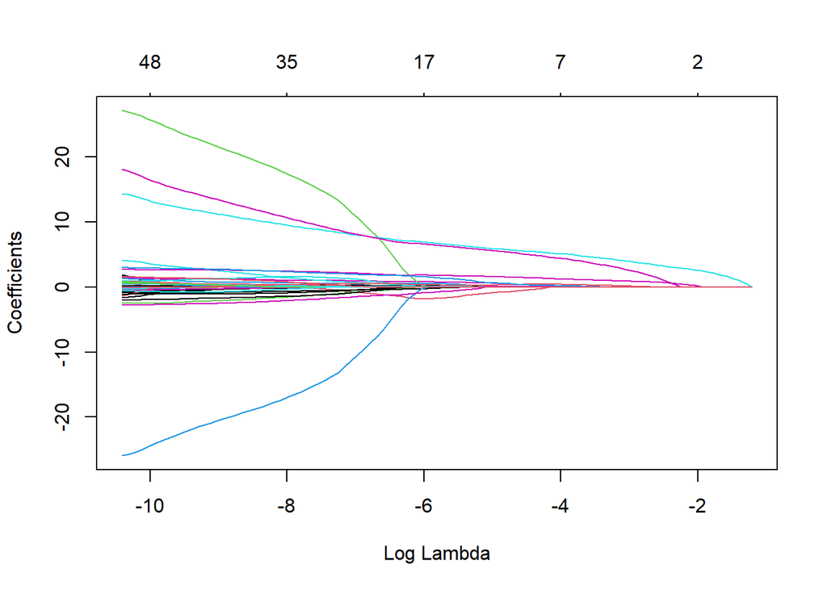

Figures 3 and 4 demonstrate the effectiveness of the LASSO regularization for this context. The final model has 19 out of 53 predictors with zeroed coefficients. As lambda increases, many predictors, indicated by the colored lines in figure 4, are eliminated from the model, likely due to colinearity or lack of predictive power, ultimately revealing the more significant predictive variables. Lambda is balanced at a point that makes the model generalizable to the testing data while retaining accuracy to the trends observed. This represents a substantively useful model for political science.

#### Figure 5: Accuracy, Specificity, Sensitivity, Confusion Matrix of the Final Logistic Classification Model

```
## Accuracy: 0.9916793
```

```
## Confusion matrix:
```

```
##              civwars_test_pred
## civwars_testY    0    1
##             0 1149    9
##             1    2  162
```

```
## Sensitivity: 0.9878049
```

```
## Specificity: 0.992228
```

### All code in this assignement

```r
knitr::opts_chunk$set(echo = FALSE, warning = FALSE, message = FALSE)
library(tidyverse)
library(glmnet)
# EXERCISE 1

# THIS CODE GENERATES FUNCTIONS TO CREATE MOCK DATA AND PROVIDE TOOLS FOR COMPARING AND EVALUATING TRAIN1 and TRAIN2 FUNCTIONS

# Set seed for reproducibility
set.seed(89)

# Function to generate IV data - 4 IVs with 1 constant and 3 in uniform distributions
genX <- function(n) {
  return(
    data.frame(X0 = 1,
               X1 = runif(n,-5,5),
               X2 = runif(n,-2,2),
               X3 = runif(n,-10, 10))
  )
}

# Function to generate outcome data as linear combination of IVs
genY <- function(X) {
  # Add noise to the linear combination of IVs
  Ylin <- 4*X$X0 + 2*X$X1 - 3*X$X2 + (1/2)*X$X3 + rnorm(nrow(X),0,0.08)
  # Normalize via sigmoid function
  Yp <- 1/(1+exp(-Ylin))
  # Convert to binary outcome
  Y <- rbinom(nrow(X),1,Yp)
  return(Y)
}

# Function to get logistic yhat predictions (1 or 0)
predict_row <- function(row, coefficients) {
  # row = a single row of the X matrix
  # coefficients = the coefficients of the linear model

  # First get values of the individual linear terms
  pred_terms <- row*coefficients
  # Then sum these up
  yhat <- sum(pred_terms)
  #Convert to probability using logit function
  return(1/(1+exp(-yhat)))
}

# Function to determine mean squared error of a model
MSE <- function(ytrue, yhat) {
  return(mean((ytrue-yhat)^2))
}

# Function to determine negative log likelihood of a model
NLL <- function(ytrue, yhat) {
  return(-sum(log(
    (yhat^ytrue)*((1-yhat)^(1-ytrue))
  )))
}

# Generate the data with 2000 rows
X <- genX(2000)
y <- genY(X)
# TRAIN 1 FUNCTION IS IDENTIFIED AS TRADITIONAL STOCHASTIC GRADIENT DESCENT, DEFINED AS FOLLOWS

train <- function(X, y, l_rate, epochs) {
  # X = training data
  # y = true outcomes
  # l_rate = learning rate
  # reps = number of SGD iterations through X

  # Instantiate model with basic guess of 0 for all coefficients
  coefs <- rep(0, ncol(X))

  # Instantiate error storage
  error_store <- data.frame(epoch = 1:epochs, MSE = rep(NA, epochs), NLL = rep(NA, epochs))

  # Start timer
  start_time <- Sys.time()

  # Iterate over epochs and random samples of x
  for (b in 1:epochs) {
    for (i in sample(1:nrow(X))) { # sampling the indices shuffles the order
      row_vec <- as.numeric(X[i,]) # make row easier to handle

      yhat_i <- predict_row(row_vec, coefficients = coefs)

      # for each coefficient, apply update using partial derivative
      coefs <- sapply(1:length(coefs), function (k) {
        coefs[k] - l_rate*(yhat_i - y[i])*row_vec[k]
      }
      )
    }

    # calculate current error
    yhat <- apply(X, 1, predict_row, coefficients = coefs)
    MSE_epoch <- MSE(y, yhat)
    NLL_epoch <- NLL(y, yhat)

    # Store the error for this epoch
    error_store[b,] <- c(b, MSE_epoch, NLL_epoch)
  }

  # End timer
  end_time <- Sys.time()

  results <- list(coefs = coefs, error_store = error_store, time_taken = end_time - start_time)

  return(results) # output the final estimates
}

coef_model <- train(X = X, y = y, l_rate = 0.001, epochs = 100)
# TRAIN 2 FUNCTION IS IDENTIFIED AS STOCHASTIC GRADIENT DESCENT WITH MOMENTUM, DEFINED AS FOLLOWS

# Note: for the purposes of visualizing the algorithim, it has been modified slightly from the original

train2 <- function(X, y, l_rate, m = 0.9, epochs) {
  # Initialize coefficients as 0
  coefs <- rep(0, ncol(X))

  # Initialize velocity as 0
  v <- rep(0, ncol(X))

  # Initialize error storage
  error_store <- data.frame(epoch = 1:epochs, MSE = rep(NA, epochs), NLL = rep(NA, epochs))

  # Start timer
  start_time <- Sys.time()

  for (b in 1:epochs) {
    for (i in sample(1:nrow(X))) {

      row_vec <- as.numeric(X[i,])

      yhat_i <- predict_row(row_vec, coefficients = coefs)

      for(k in 1:length(coefs)) {

        v[k] <- m*v[k] + l_rate*(yhat_i - y[i])*row_vec[k]

        coefs[k] <- coefs[k] - v[k]
      }
    }

    yhat <- apply(X, 1, predict_row, coefficients = coefs)
    MSE_epoch <- MSE(y, yhat)
    NLL_epoch <- NLL(y, yhat)

    # Store the error for this epoch
    error_store[b,] <- c(b, MSE_epoch, NLL_epoch)
  }

  # End timer
  end_time <- Sys.time()

  results <- list(coefs = coefs, error_store = error_store, time_taken = end_time - start_time)
  return(results)
}
coef_model2 <- train2(X = X, y = y, l_rate = 0.001, epochs = 100)

# combine the two error stores together
error_store <- coef_model2$error_store %>%
  select(NLL, MSE) %>%
  rename(SGD2_NLL = NLL, SDG2_MSE = MSE) %>%
  cbind(coef_model$error_store, .) %>%
  rename(SGD1_NLL = NLL, SGD1_MSE = MSE)
# Plot the error over time
library(ggplot2)

#Negative log-likelihood
ggplot(error_store, aes(x = epoch)) +
  geom_line(aes(y = SGD1_NLL, color = "red")) +
  geom_line(aes(y = SGD2_NLL, color = "blue")) +
  theme_minimal() +
  labs(x = "Epoch", y = "Loss Function (negative log likelihood)") +
  theme(legend.position = "top") +
  scale_color_manual(values = c("red", "blue"), labels = c("Stochastic Gradient Descent (train1)", "Stochastic Gradient Descent with Momentum (train2)"))
# Neat dataframe for presenting model comparison results
results_df_SGD_SGDM <- tibble(
  Method = c("Traditional Stochastic Gradient Descent", "Stochastic Gradient Descent with Momentum"),
  Time_Taken = c(coef_model$time_taken, coef_model2$time_taken),
  Final_Coefficients = c("3.1660217  1.6327201 -2.4372223  0.3872164", "3.6808136  1.8921464 -2.7876448  0.4938963"),
  Final_NLL = c(tail(coef_model$error_store$NLL, 1), tail(coef_model2$error_store$NLL, 1))
)

# Print the DataFrame
print(results_df_SGD_SGDM)
# Define the best model function - Note this function includes many contingent functions that are defined within the function
best_model <- function(x,y) {

# FIRSTLY - DEFINE THE FUNCTIONS THAT WILL BE USED IN THE MODEL TRAINING AND VALIDATION PROCESS

  #standardize the data
  standardize <- function(x) {
    return((x - mean(x)) / sd(x))
  }

  # Generate n-degree polynomial vector function
  generate_poly_features <- function(x, degree) {
    # x is a vector of predictor variable
    # degree is the degree of the polynomial
```

```r
    # Generate polynomial features function
    poly_features <- matrix(NA, nrow = length(x), ncol = degree)
    for (i in 1:degree) {
      poly_features[,i] <- x^i
    }
    return(poly_features)
  }

  # Generate ridge loss function
  ridgeLoss <- function(ytrue, yhat, coefficients, lambda) {
    mse <- MSE(ytrue, yhat)
    l2_penalty <- lambda*sum(coefficients^2)
    return(mse + l2_penalty)
  }

  # Generate mean squared error function
  MSE <- function(ytrue, yhat) {
    error <- ytrue - yhat
    loss <- 1/length(y) * sum(error^2)
    return(loss)
  }

  # DEFINE THE STOCHASTIC GRADIENT DESCENT FUNCTION WITH RIDGE REGULARIZATION
  sgd_ridge_regression <- function(x, y, lambda, l_rate=0.001, epochs = 100, degree) {
    # x is a vector of predictor variable
    # y is a vector of true outcome variable
    # lambda is the regularization parameter
    # learning_rate is the step size for gradient descent
    # epochs is the number of iterations
    # Note: function assumes x and y are standardized, so y-intercept is estimated at 0, no need to regularize it


    # Firstly, get polynomial features, with intercept at index 0
    x_poly <- generate_poly_features(x, degree)

    # Randomly initialize a number of coefficients equal to degree
    coefs <- runif(ncol(x_poly), -0.5, 0.5)

    # Loop through epochs
    for(epoch in 1:epochs) {
      # Loop through random samples (stochastic gradient descent)
      for(i in sample(1:length(x))) {
        # Get current x and y
        x_var <- x[i]
        y_var <- y[i]

        # get matching polynomial values for current x
        x_poly_i <- generate_poly_features(x_var, degree)

        # Get predicted y using current coefficients and polynomial values of current x
        yhat_i <- sum(coefs * x_poly_i)

        # Apply update to each coefficient using partial derivative
        coefs <- sapply(1:length(coefs), function (k) {
          # Get gradient for current x
          grad <- (yhat_i - y_var)*x_var
          l2_penalty <- 2*lambda*coefs[k]
          # Update coefficients
          coefs[k] - l_rate*(grad + l2_penalty)
        }
        )
      }
      # Calculate yhat for all x using current coefficients
      yhat <- rowSums(x_poly * coefs)
      # Calculate loss for current epoch: sum of squared residuals + l2 penalty
      loss_epoch <- ridgeLoss(y, yhat, coefs, lambda)

     return(coefs)
     }}

  # DEFINE THE CROSS VALIDATION FUNCTION FOR K-FOLDS
  generate_k_folds <- function(x, y, k = 5) {
    #This approach involves randomly dividing the set of observations into k groups, or folds, of approximately equal size. The first fold is treated as a validation set, and the method is fit on the remaining k − 1 folds.


    # x is a vector of predictor variable
    # y is a vector of true outcome variables, same length
    # k is the number of folds, 5 is default

    # Number of observations
    n <- length(x)

    # Create a sequence of indices
    indices <- sample(1:n)

    # Calculate the size of each fold
    fold_size <- ceiling(n / k)

    # Initialize a list to store the folds
    folds <- vector("list", k)

    # Generate the folds
    for(i in 1:k) {
      # Calculate start and end indices for the fold
      start_index <- ((i - 1) * fold_size) + 1
      end_index <- min(i * fold_size, n)

      # Get the indices for the current fold
      fold_indices <- indices[start_index:end_index]

      # Extract the data for the current fold
      folds[[i]] <- list(
        x_train = x[-fold_indices],
        y_train = y[-fold_indices],
        x_test = x[fold_indices],
        y_test = y[fold_indices]
      )
    }

    return(folds)
  }


  # Now all functions have been defined, we standardize the data to make it suitable for ridge regularization
  x <- standardize(x)
  y <- standardize(y)

  # Next, we define a hyper parameter search method to iterate over different degrees and lambda values, trying to find a minimum of the variance and bias trade off
  # The chosen search method is a semi-random grid search with discrete degree values and 30 bounded random values for the continuous lambda parameter, clustered around lambda < 1

    degrees <- 1:7
    lambda_values <- c(runif(10, 0, 0.1), runif(10, 0.1, 1), runif(10, 1, 10))
    best_loss <- Inf
    best_model <- NULL
    best_degree <- NULL
    best_lambda <- NULL

      # Split data for cross-validation, use k = 5 as a good default for number of splits, not too large but still sufficient for cross validation
      folds <- generate_k_folds(x, y, k = 5)

      # perform grid search for finding optimal model hyper parameters
      for(degree in degrees) {
        for(lambda in lambda_values) {
          # perform cross-validation and model training over k folds for each hyperparameter combination
          loss_vec <- c()
          for (fold in folds) {
            x_train <- fold$x_train
            y_train <- fold$y_train
            x_val <- fold$x_test
            y_val <- fold$y_test
            # Train a new model for each of the 5 folds' train-test split
            model_weights <- sgd_ridge_regression(x_train, y_train, lambda, degree = degree)

            # Perform validation step, determine loss on validation data
            x_val_poly <- generate_poly_features(x_val, degree)
            yhat <- rowSums(x_val_poly * model_weights)
            loss <- ridgeLoss(y_val, yhat, model_weights, lambda)
            loss_vec <- c(loss_vec, loss) # store the result

          }

          # Compare model accuracy (minimum loss) for current hyper parameters against previous
          # Final model score is taken as the average loss on the validation across the k folds
          loss <- mean(loss_vec)
          # if loss less than minimum previously observed, update it
            if(loss < best_loss) {
              best_loss <- loss
              best_model <- model_weights
              best_degree <- degree
              best_lambda <- lambda
            }
          }
          }
```

```r
    cat("Optimal Model Form as follows:\n", "Optimal polynomial degree is", best_degree, "\nOptimal lambda is", best_lambda, "\nOptimal model weights are", best_model)
    cat("\nBest Validation Loss:", best_loss)
  return(list(best_model, best_degree, best_lambda, best_loss))
}
# Load in the raw civil war data
load("civil_wars.RData")

# Split the data into training and testing based on 80/20 split
set.seed(123)
indices <- sample(1:nrow(civwars))
split_index <- round(nrow(civwars) * 0.8)
civwars_train <- civwars[indices[1:split_index],]
civwars_test <- civwars[indices[(split_index+1):nrow(civwars)],]

# Split the training data into predictors and outcome
civwars_trainX <- as_tibble(civwars_train) %>%
  select(-c(2:9)) # Remove the irrelevant outcome variables
civwars_trainY <- civwars_train$war

# Train the model using the training data, with k = 10 folds
# 10 Folds is a common choice for k, and provides sufficient validation sets for minimizing bias and variance
# Note that cv.glmnet automatically standardizes the predictors, otherwise it would be included as a data processing step
lasso_cv <- cv.glmnet(as.matrix(civwars_trainX), civwars_trainY, alpha = 1, family = "binomial", nfolds = 10)

# Extract the optimal lambda value for the L1 penalty term
lambda_min <- lasso_cv$lambda.min

# Train final model using the optimal lambda value from cross validation
final_mod <- glmnet(as.matrix(civwars_trainX), civwars_trainY, alpha = 1, lambda = lambda_min, family = "binomial")
# get coefficients
coef(final_mod)
plot(lasso_cv$glmnet.fit, "lambda")
# Test the model using the testing data
civwars_testX <- as_tibble(civwars_test) %>%
  select(-c(2:9))

civwars_testY <- civwars_test$war

# Predict the outcome using the test data
civwars_test_pred <- predict(final_mod, newx = as.matrix(civwars_testX), s = lambda_min, type = "response")

# Calculate the accuracy of the model: a standard evaluation for logistic classification equations
civwars_test_pred <- ifelse(civwars_test_pred > 0.5, 1, 0)
accuracy <- mean(civwars_test_pred == civwars_testY)
cat("Accuracy:", accuracy, "\n")

# Calculate the confusion matrix
cat("Confusion matrix:\n")
confusion_matrix <- table(civwars_testY, civwars_test_pred)
print(confusion_matrix)

# Calculate the sensitivity and specificity
sensitivity <- confusion_matrix[2,2] / sum(confusion_matrix[2,])
specificity <- confusion_matrix[1,1] / sum(confusion_matrix[1,])

cat("Sensitivity:", sensitivity, "\n")
cat("Specificity:", specificity, "\n")

# this chunk generates the complete code appendix.
# eval=FALSE tells R not to run (``evaluate'') the code here (it was already run before).
```

### Works Cited

Kochnderfer, Mykel J, and Tim A Wheeler. Algorithms for Optimization. Cambridge, Massachusetts Etc., The Mit Press, 2019.

Nesterov, Yurii. “A method for solving the convex programming problem with convergence rate O(1/k^2).” Proceedings of the USSR Academy of Sciences 269 (1983): 543-547.